# HW3

Home Work 3-Data Mining Apeksha Hada

1. Answer the following? [50 pts] a) Write and explain about the Linear Regression and its equation [3 pts] Answer:

Two most popular learning algorithms ■ Linear regression ■ Logistic regression

To performance supervised learning, we must decide how we’re going to represent function h. A simple choice is a linear function of x.

```python
%%html
<img src="LR.png", width=500,height=500>
```

[figure not shown]

b) Explain in detail about the loss function of linear regression, R2, Adjusted R2 used in the Linear Regression and what is the need for Adjusted R2? [12 pts]

Loss or error or MSE:

Below is the formula for loss

```python
%%html
<img src="loss.png", width=500,height=500>
```

[figure not shown]

R-squared is a statistical measure of how close the data are to the fitted regression line. R-squared is a goodness-of-fit measure for linear regression models.

Some Problems with R-squared: Problem 1: Every time you add a predictor to a model, the R-squared increases, even if due to chance alone. It never decreases. Consequently, a model with more terms may appear to have a better fit simply because it has more terms.

Problem 2: If a model has too many predictors and higher order polynomials, it begins to model the random noise in the data. This condition is known as overfitting the model and it produces misleadingly high R-squared values and a lessened ability to make predictions.

Adjusted R-squared: The adjusted R-squared is a modified version of R-squared that has been adjusted for the number of predictors in the model. The adjusted R-squared increases only if the new term improves the model more than would be expected by chance. It decreases when a predictor improves the model by less than expected by chance. The adjusted R-squared can be negative, but it’s usually not. It is always lower than the R-squared.

c) Plot X vs Y in Scatter plot from data in Table 1 and comment on the relation of X vs Y using Covariance, Correlation. Please comment on Covariance and correlation values [5 Pts]

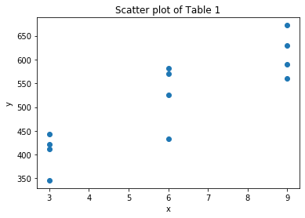

```python
import matplotlib.pyplot as plt

X = [6,3,6,9,3,9,6,3,9,6,3,9]
Y = [526,421,581,630,412,560,434,443,590,570,346,672]

plt.scatter(X,Y)
plt.title('Scatter plot of Table 1')
plt.xlabel('x')
plt.ylabel('y')

plt.show()
```

```python
import numpy as np

x = np.stack((X, Y), axis=0)
print(x)
print()

covariance = np.cov(x)
correlation = np.corrcoef(X, Y)

print('covariance: ')
print(covariance)
print()
print('correlation: ')
print(correlation)
```

```
[[  6   3   6   9   3   9   6   3   9   6   3   9]
 [526 421 581 630 412 560 434 443 590 570 346 672]]

covariance:
[[6.54545455e+00 2.26363636e+02]
 [2.26363636e+02 1.02522652e+04]]

correlation:
[[1.         0.87382978]
 [0.87382978 1.        ]]
```

Covariance can be classified as positive covariance (two variables tend to vary together) and negative covariance (one variable is above or below the expected value compared to another variable)

When you say that two items correlate, you are saying that the change in one item effects a change in another item. For example in above case, if you say that two items have a correlation of 0.87 you are saying that a change in one item results in a similar change to another item.

d) Perform Linear regression on the following data using Python? and print β0, β1 values in equation y= β0+ β1*x. Please write down what is your understanding from those values. [10 Pts]

```python
from sklearn.linear_model import LinearRegression
in1 = np.array(X).reshape((-1,1))
in2 = np.array(Y)

model = LinearRegression()
model.fit(in1, in2)

print('b0:', model.intercept_)
print('b1:', model.coef_)
```

```
b0: 307.91666666666663
b1: [34.58333333]
```

e) What are different evaluation metrics available for predicting the performance of the Linear Regression? Evaluate all those methods on the given dataset in Table 1 and also please print out the accuracy, R2, Adjusted R2 [10 pts]

```python
from sklearn.metrics import mean_squared_error
from sklearn.metrics import mean_absolute_error

r_sq = model.score(in1, in2)
print('coefficient of determination(R^2):', r_sq)

n = len(X)
p = 1
adj_R2 = 1-(1-r_sq ** 2)*((n-1)/(n-p-1))

print("Adjusted R^2: ", adj_R2)

y_pred = model.predict(in1)
MSE = mean_squared_error(in2, y_pred)

print("Mean Sq. Error (MSE): ",MSE)
print("Mean Abs. Error: ",mean_absolute_error(in2, y_pred))
print("RMSE: ",np.sqrt(mean_squared_error(in2, y_pred)))
```

```
coefficient of determination(R^2): 0.7635784848728921
Adjusted R^2:  0.5413573128168596
Mean Sq. Error (MSE):  2221.868055555555
Mean Abs. Error:  39.23611111111112
RMSE:  47.136695424642944
```

1. Answer the following [30 Pts] a) What is Conditional probability, Marginal probability and Joint probability? Write their mathematical formulas and give one example each. [5 pts]

Answer: The conditional probability of an event B is the probability that the event will occur given the knowledge that an event A has already occurred. This probability is written P(B|A), notation for the probability of B given A.

```python
%%html
<img src="Prob.png", width=500,height=500>
```

[figure not shown]

Marginal probability: Probability of a single event irrespective of any other event. For instance, the probability of a coin flip giving a head is considered a marginal probability because we aren’t considering any other events.

Joint probability: The probability of two events occurring simultaneously. The probability of the intersection of A and B may be written p(A ∩ B). Example: the probability that a card is a four and red =p(four and red) = 2/52=1/26. (There are two red fours in a deck of 52, the 4 of hearts and the 4 of diamonds).

b) Explain what is Baye’s rule with the formula and what is prior, posterior, likelihood and marginal probability in the Baye’s rule. [10 pts]

Answer: Bayes’ theorem or Bayes’ rule describes the probability of an event, based on prior knowledge of conditions that might be related to the event. For example, if cancer is related to age, then, using Bayes’ theorem, a person's age can be used to more accurately assess the probability that they have cancer than can be done without knowledge of the person’s age.

P(A|B): Conditional probability: Posterior P(A) and P(B): Marginal Probability: Prior P(B|A): Conditional probability: Likelihood. The posterior is proportional to the prior times the likelihood.

c) What is Naive Bayes algorithm and how is related or derived or inspired from Bayes rule? [5 pts]

Answer: Naive Bayes is a simple technique for constructing classifiers: models that assign class labels to problem instances, where the class labels are drawn from some finite set. All naive Bayes classifiers assume that the value of a particular feature is independent of the value of any other feature, given the class variable.

Relation with Bayes rule: The classification is carried out by calculating the posterior probabilities and finding the hypothesis with the highest probability using Bayes rule. It is referred to as naive because it assumes all features are independent, which is rarely the case in real life.

d) Perform Naive Bayes algorithm on the below dataset in python in which you can classify whether a Red Domestic SUV is stolen or not as shown in 2.2. [10 pts]

```python
%%html
<img src="Car.png", width=500,height=500>
```

[figure not shown]

```python
# Assigning features and label variables
color =['red','red','red','yellow','yellow','yellow','yellow','yellow','red','red']
type_of_car=['sports','sports','sports','sports','sports','suv','suv','suv','suv','sports']
origin=['domestic','domestic','domestic','domestic','imported','imported','imported','domestic','imported','imported']
stolen=['yes','no','yes','no','yes','no','yes','no','no','yes']

from sklearn import preprocessing
#creating labelEncoder
le = preprocessing.LabelEncoder()
# Converting string labels into numbers.

color_encoded=le.fit_transform(color)
print(color_encoded)

type_encoded=le.fit_transform(type_of_car)
print(type_encoded)

origin_encoded=le.fit_transform(origin)
print(origin_encoded)

label=le.fit_transform(stolen)
print('Stolen? :',label)
```

```
[0 0 0 1 1 1 1 1 0 0]
[0 0 0 0 0 1 1 1 1 0]
[0 0 0 0 1 1 1 0 1 1]
Stolen? : [1 0 1 0 1 0 1 0 0 1]
```

```python
#Combinig into single listof tuples
features=[(0,0,0),(0,0,0),(0,0,0),(1,0,0),(1,0,1),(1,1,1),(1,1,1),(1,1,0),(0,1,1),(0,0,1)]
print(features)
```

```
[(0, 0, 0), (0, 0, 0), (0, 0, 0), (1, 0, 0), (1, 0, 1), (1, 1, 1), (1, 1, 1), (1, 1, 0), (0, 1, 1), (0, 0, 1)]
```

```python
#Import Gaussian Naive Bayes model
from sklearn.naive_bayes import GaussianNB

#Create a Gaussian Classifier
model = GaussianNB()

# Train the model using the training sets
model.fit(features,label)

#Predict Output
predicted= model.predict([[0,1,0]]) # 0:No, 1:Yes
print("Predicted Value:", predicted)
```

```
Predicted Value: [0]
```